# Forecasting Parking Demand - Numbers of Vacant Spots in Seattle

Yixuan Hu and Yuchen Zhang

December 21, 2018

## 1 Introduction

Searching for parking becomes a challenging task in the city around the world<sup>1</sup>. Discussing vacant spots is one way to reflect the parking demands. Parking demands highly relate to the social behaviors of citizens who commute back and forth within the city. Moreover, parking demands have high spatial dynamics and temporal dynamics. That is, parking demands vary at different time or date, and in different locations<sup>2</sup>. Even the drivers are familiar with the surrounding environment, it is still difficult for them to find a vacant spot since they lack the dynamic information within an exact space and time. The activity of cruising for curbside parking contributes to traffic congestion. The purpose of this project is to build a model to predict the parking demands in terms of numbers of vacant spots on a blockface scale.

Both drivers and traffic operators will have great interest in the prediction model: for drivers, the model can offer them the information on the numbers of vacant spots in specific locations and time that can potentially help drivers find available parking spots more efficiently in a timely manner; helping drivers is also helping the city, because we can mitigate the traffic congestion if the “cruising” behavior is alleviated.

However, an accurate prediction is difficult to achieve since there are so many factors that may influence the numbers of vacant spots. For example, the traffic flow in that specific time and location, the road characteristics in that space and the walkable distance to the final destination will all affect the drivers’ decisions. Spatial variables such as distance to schools, distance to tourist attractions and distance to Centric Business District will also have impacts on the numbers of vacant spots. Feature engineering can not only help us figure out the dominant factors but also the degree of impact.

Our overall modeling strategy is to introduce **16** predictors (independent variables) within our model to determine the numbers of vacant spots in the city of Seattle using Poisson Distribution. Due to the limiting computing power of our laptops and the quality of the dataset, we have to narrow our predictors from 45 to 16. After associated with the numbers of vacant spots, factors will be judged by their correlation and MAE (Mean Absolute Error). 25% test sample prediction and cross-validation (including spatial and temporal one) will also help to ensure the generalizability and accuracy of the predictive model.

## 2 Data

Data are mainly extracted from the *City of Seattle Open Data* portal. General Parking Information data such as Parking Space, Total_Vehicle_Count, Peak Hour and Road Types in large scales are from *Annual Parking Study Dataset*; Count_Flow Data are from *2016 Traffic Flow Counts Dataset*; Street classifications and conditions in small scales are from *Seattle Streets Dataset*. Geographic locations for different locations are either shapefiles from *Open Data Portal*, such as public transit dataset and schools dataset, or geographic-coordinate from Google map. All the spatial data are projected by *NAD 1983 StatePlane Washington North FIPS 4901 in Meters*.

### 2.1 Model Description

In our prediction model, the dependent variable that represents the parking demands is the numbers of vacant spots. It is the function of the built environment that contains spatial and temporal factors, and the road characteristics. Our independent variables will totally have **16** predictors and fall into four categories, which are spatial predictors, temporal predictors, road characteristic predictors, and social predictors.

For the dependent variable, the number of vacant spots will be calculated from parking space and total vehicle counts. There are some negative numbers after subtracting the `parking_space` by `total_vehicle_counts`, because some areas will be over-parked. We replace all negative numbers by 0. The entire model will be predicted by **Poisson regression** because the model contains too many 0 that is not reasonable to use the linear regression model.

### 2.2 Exploratory Analysis

#### 2.2.1 Summary

List of Variables

| Variables | Description | Categories |
| --- | --- | --- |
| vacancy_spot2 | Numbers of Vacant Spots (calculating by Parking Spaces and Total_Vehicle_Count) | Dependent Variables |
| Subarea.Label | Paid Parking Sub Area | Saptial Predictor |
| PeakHour | Peak Hour (Y/N) | Temporal Predictor |
| SURFACETYP | Surface Type | Road Characteristic Predictor |
| NATIONHWYS | Nation Highways | Road Characteristic Predictor |
| STREETTYPE | Street Types | Road Characteristic Predictor |
| Count_flow | Average Annual WeekDay Traffic (AAWDT) | Spatial Predictor |
| rate_morning | Morning Parking Fee (8am-11am) | Spatial Predictor |
| rate_midday | Daytime parking fee(11am-5/6pm) | Saptial Predictor |
| rate_evening | Evening parking fee(5pm-8/10pm) | Saptial Predictor |
| Zoning_class | Zoning Classification | Spatial Predictor |
| popDens_m2 | 2016 Population Density | Social Predictor |
| distanceAttraction | Distance to Tourist Attractions | Spatial Predictor |
| distanceGarage | Average Distance to Nearest 3 Parking Garages | Spatial Predictor |
| distanceSchool | Average Distance to nearest 3 Schools | Spatial Predictor |
| distanceTransit | Average Distance to nearest 3 Public Transits | Spatial Predictor |
| distanceCBD | Distance to CBD | Spatial Predictor |
| distGarage5 | Average Distance To nearest 5 Garages | Spatial Predictor |
| distAttraction3 | Average Distance To Nearest 3 Tourist Attractions | Spatial Predictor |
| distAttraction5 | Average Distance To Nearest 5 Tourist Attractions | Spatial Predictor |
| distSchools5 | Average Distance To Nearest 5 Schools | Spatial Predictor |
| distSchools9 | Average Distance To Nearest 9 Schools | Spatial Predictor |
| distTransit1 | Distance to Public Transit | Spatial Predictor |
| distTransit5 | Average Distance to Nearest 5 Public Transits | Spatial Predictor |
| distOffice4 | Average Distance to Nearest 4 Office Buildings | Spatial Predictor |
| dotw | Day of Week | Temporal Predictor |
| hour_categ | Hour (Catagorical) | Temporal Predictor |
| Road_classifi_fac | Road Classification | Road Characterisric Predictor |
| speedLimit_fac | Speed Limit in MPH | Road Characterisric Predictor |
| PVM_condi_fac | Pavement Condition | Road Characterisric Predictor |
| Slope_fac | Slope | Road Characterisric Predictor |
| Hood_ID_fac | Neighborhood | Spatial Predictor |
| Hour_fac | Hour (Factor) | Temporal Predictor |
| surr_price_mean_3 | Average Vacant spots for nearest 3 parking spots | Spatial Predictor |
| surr_price_med_3 | Median vacant spots for nearest 3 parking spots | Spatial Predictor |
| surr_price_mean_5 | Average vacant spots for nearest 5 parking spots | Spatial Predictor |
| surr_price_med_5 | Median vacant spots for nearest 5 parking spots | Spatial Predictor |
| median_VacantSpot_time | Median Vacant Spot at This Specific Time | Temporal Predictor |
| mean_VacantSpot_time | Average Vacant Spot at This Specific Time | Temporal Predictor |

#### 2.2.2 Spatial and Temporal Variation

Figure below shows the map of average numbers of vacant spots (dependent variable). We can see that the average numbers of vacant spots, in reality, is ranging from 0 to 3.8.

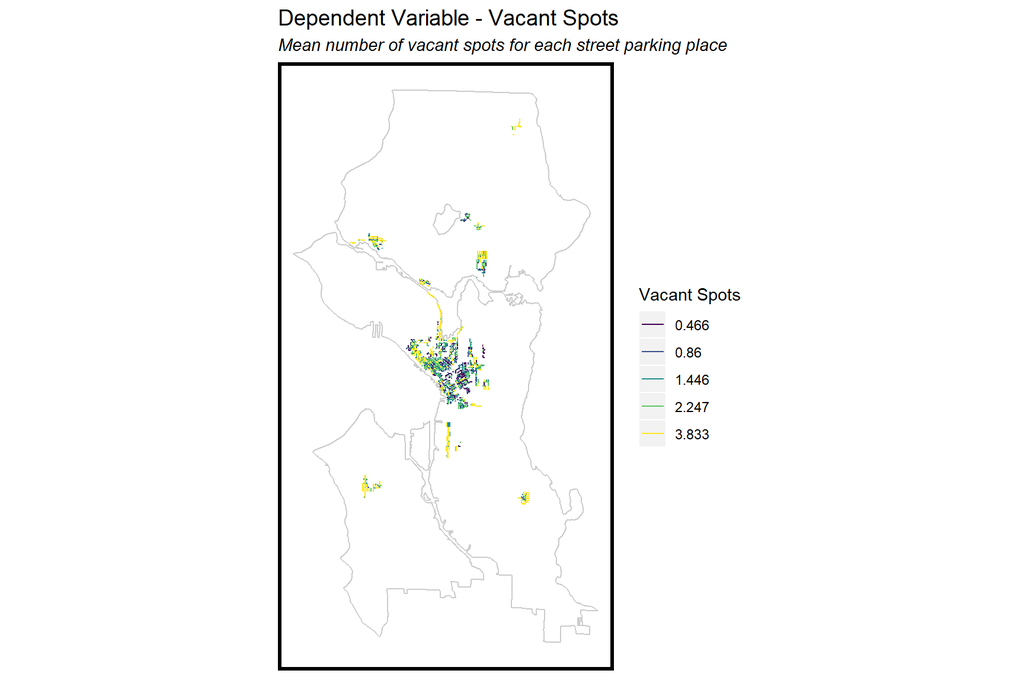

From the figure below, we can see that parking records have different clustered patterns in downtown area. This means that each blockface have extremely different numbers of records.

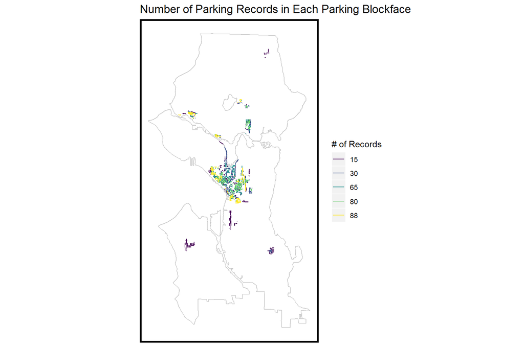

Number of each variables in Day Of Week

| Day of Week | Count |
| --- | --- |
| Sun | 1900 |
| Tue | 40745 |
| Wed | 29957 |
| Thu | 27372 |
| Sat | 1758 |

Number of each variables in Time of Day

| Time of Day | Count |
| --- | --- |
| Morning | 42484 |
| Midday | 21568 |
| Evening | 20892 |
| Other | 16788 |

### 2.3 Correlation

Correlation is used to analyze the pairwise correlation between the numbers of vacant spots and its predictor variables. The correlation matrix is built to intuitively visualize the relationships between independent variables.

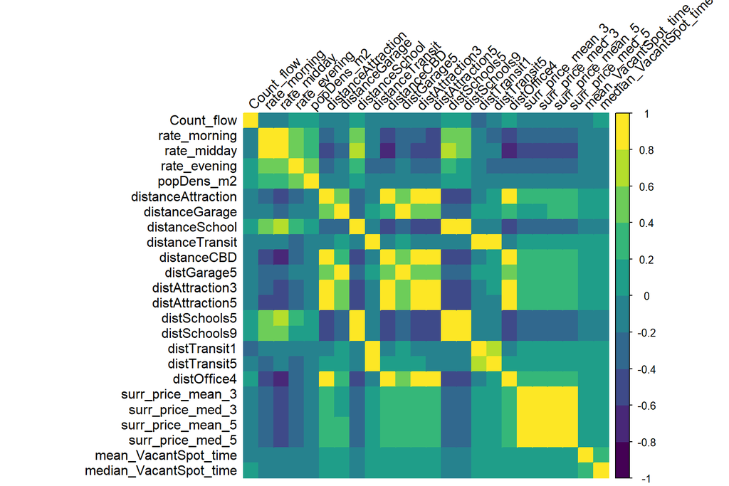

Above correlation matrix shows that the strong correlation appears among spatial variables, such as distance to schools and distance to garages, and temporal variables, such as midday parking rate. Even though these variables have a strong correlation, they are still very essential in our models. Therefore, we do not drop these variables.

### 2.4 Maps of Variables

#### 2.4.1 Distribution of Dependent Variable

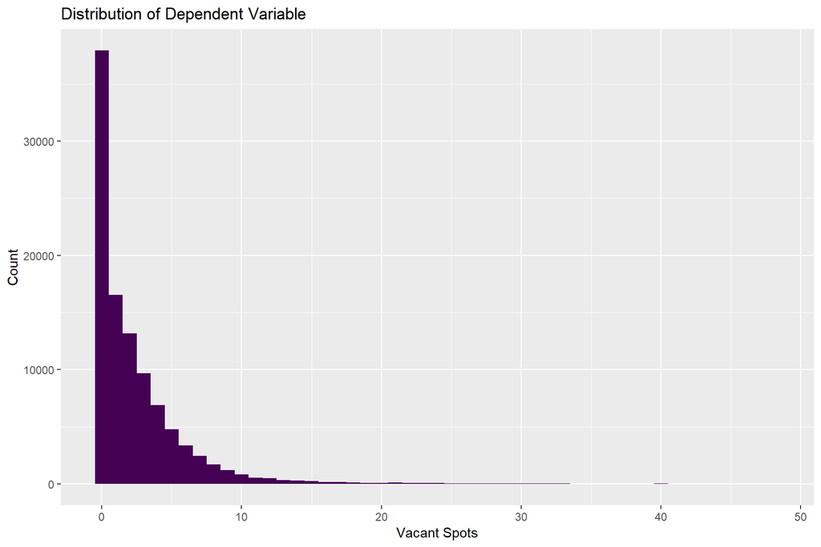

#### 2.4.1 Map of Some Interesting Predicted Variables

Figure below shows the map of the numbers of vacant spot with the association of mean vacant spots of surrounding nearest 3 parking spots.

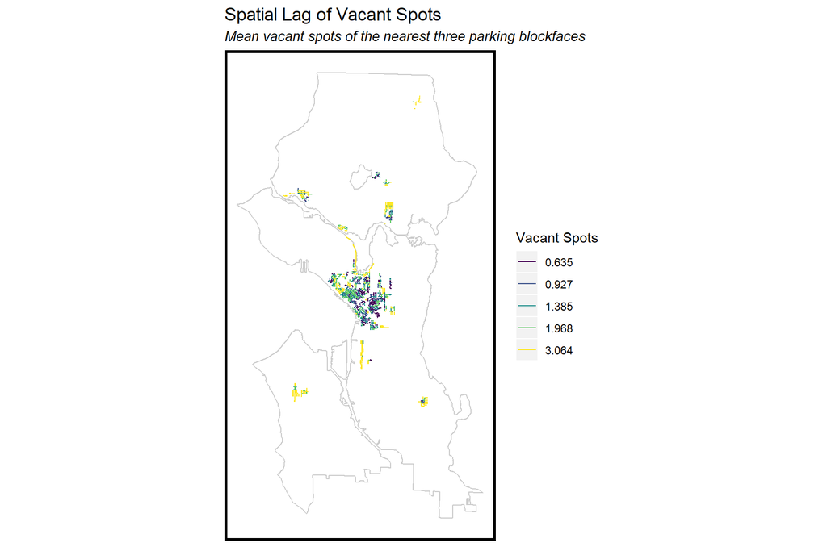

We can see that most garages are in downtown, therefore, less average distance appears in downtown, most average distance appears in the peripheral area.

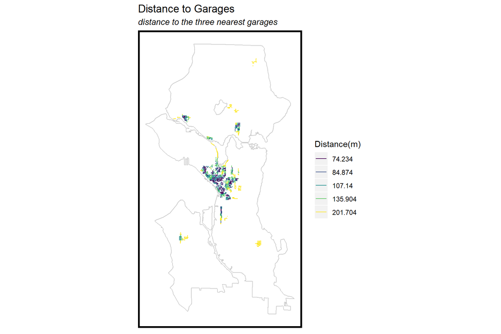

We gathered the location of the most popular tourist attraction and restaurants in Seattle because we think these places attract people to visit and have high demand for parking.

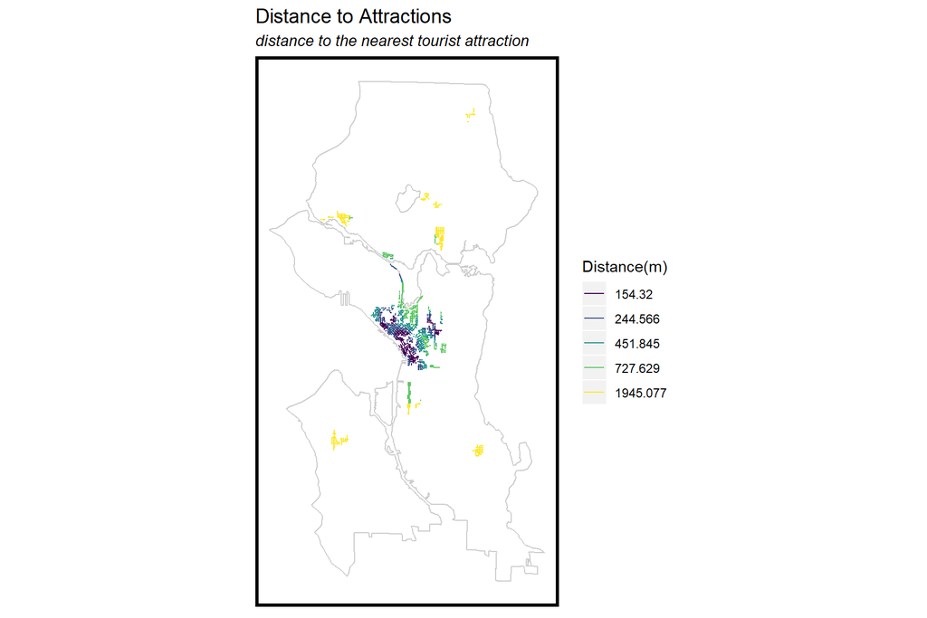

## 3 Method

The research methods can be generally separated into three parts: data wrangling, building the predictive model and testing the model.

### 3.1 Data Wrangling

We introduce potential factors that will influence the real situations in the specific time and location, which might affect drivers’ parking behaviors. For example, locations of schools, tourist attractions, and office buildings will influence peak hours, traffic flows in the morning and middays. The density of these specific infrastructures will also affect the parking demands in that surrounding area and ultimately influence the vacant spots. Therefore, Average Distance to nearest numbers of public infrastructures is an important variable.

Right now, the scale of our model is blockface. In order to calculate the distance, using K-Nearest Neighbor method, we need to transform the line data (blockface) into point data first. Therefore, we use mid-point of each blockface to represent that blockface. In the end, we will assign those point data back to the related blockface again. Besides numerical variables, we also include many categorical variables, such as road characteristics such as street classification and slope.

The temporal predictor is another important type in our model. Basically, all temporal data will be separated into three periods: morning (8am-11am); midday (11am-5/6pm); and evening (5pm-8/10pm). Because we find that daily parking fees are different in the same place by three different periods as we mentioned above.

### 3.2 Building a Predictive Model

We select the data that tend to associate with independent variables but not correlated with each other. For categorical data, we change them to be dummy variables. Then we use Poisson regression to build the predictive model.

### 3.3 Testing the Model

We basically test the predictive model in two ways: in-sample prediction and 25% test-sample prediction. In the in-sample prediction, we test the entire dataset and judge the accuracy of the result by the standardized coefficient and mean absolute error (MAE). In the 25% test-sample prediction, we test the model by k-fold cross-validation to ensure the generalizability of the model. Since temporal and spatial variables are vitally important in our model, we will also test the spatial cross-validation and temporal cross-validation to check the generalizability. Moran’s I is also calculated to check the spatial auto-correlation of the model.

## 4 Result

### 4.1 In-sample Model

#### 4.1.1 Standardized Coefficient

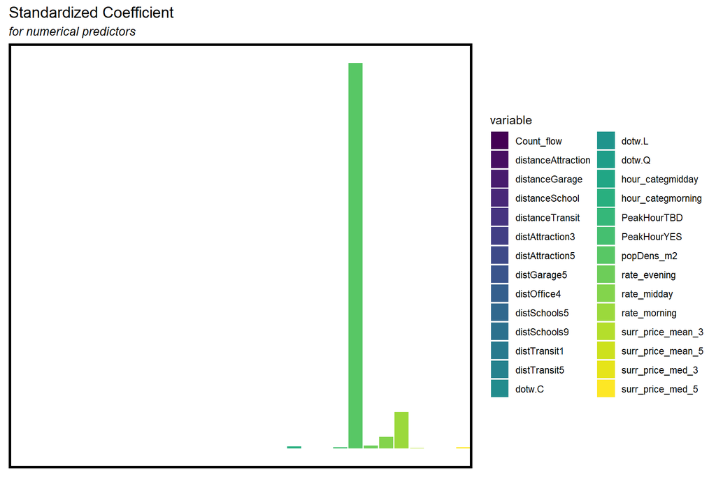

Figure above represents the standardized coefficients for all numerical variables and some categorical variables. We can see that the most important variable here is the population density in 2016. This means that the spatial location of people has a strong influence on the model.

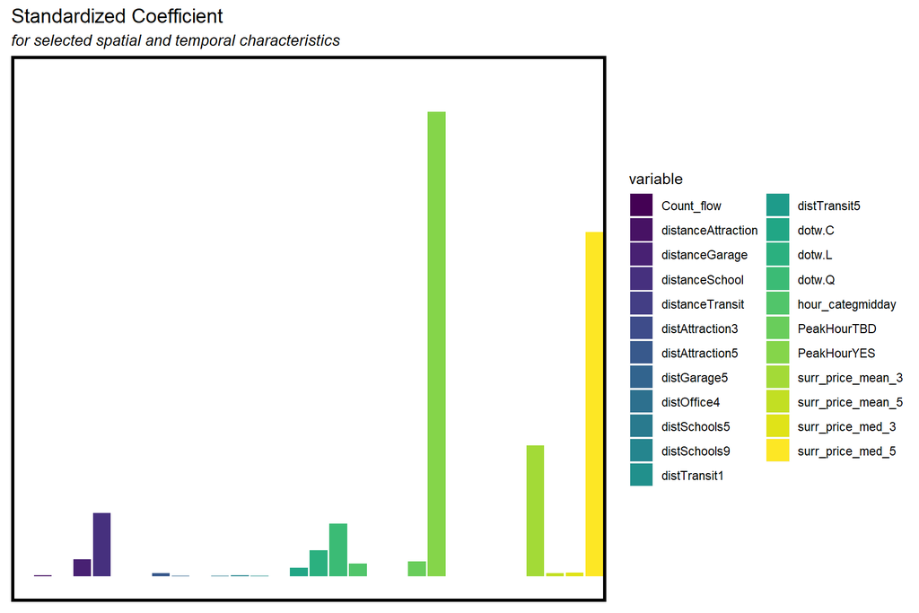

The figure above only includes the spatial and temporal numeric variables. We can see that peak hour (Y/N) has a relatively most strong influence on a model as a temporal variable. Meanwhile, median numbers of nearest several vacant spots also has strong relation with dependent variable as a spatial variable. Distance to nearest schools and garage also effectively affect the model as spatial variables.  
For peak hour, the peak hour for each street is different. The coefficient demonstrates that peak hour is more important in the model that time itself.

#### 4.1.2 Prediction Results

The result of the in-sample regression model is shown as below, which is **1.82**.

We can tell that points are scattered in the figure below. Those diffused points may tag the yellow line which influences the final prediction. From the figure, we can see that the yellow line is a bit far away from the purple line (the predicted perfect model). That is, the accuracy of the model is moderate. We still need to improve our model some way.

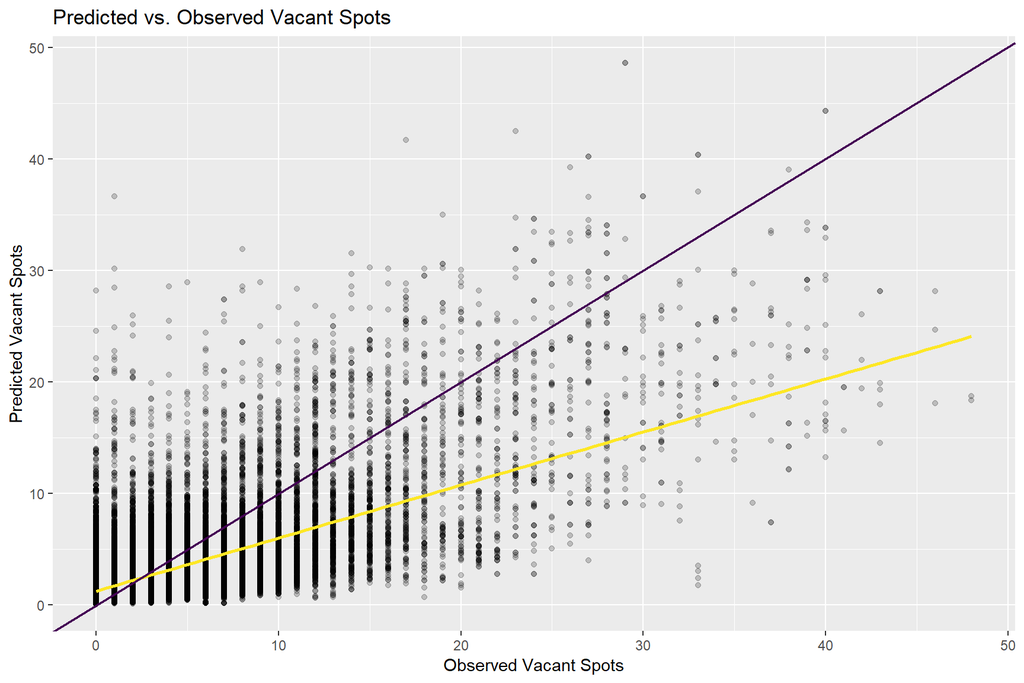

Figure below shows the predicted numbers of vacant spots. We can see that the average numbers of vacant spots are pretty small, range from 1 spot to 3 spots. Lots of parking spots in downtown area has only or less than 1 vacant spot.

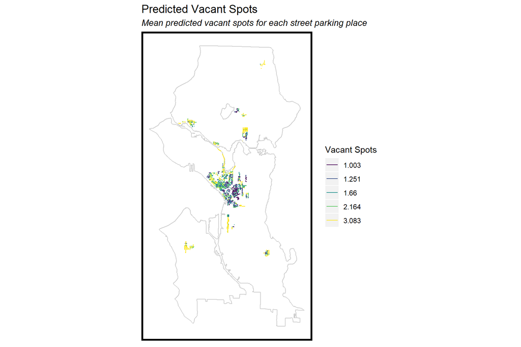

Figure below shows the predicted numbers of vacant spots in four time categories: evening, midday, morning and others.

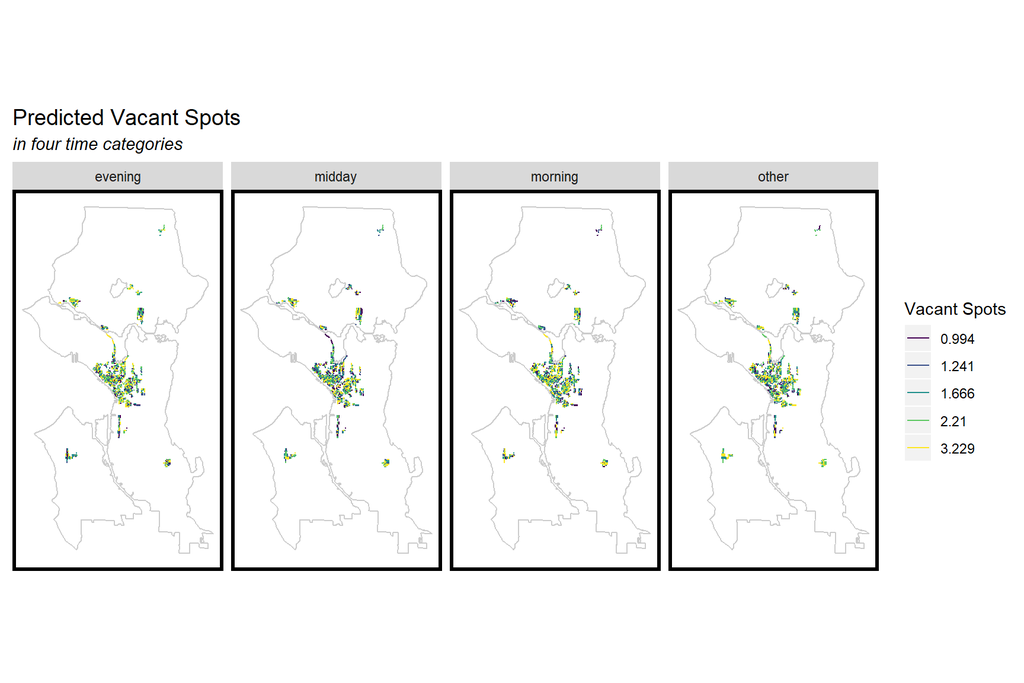

In the plot below, we can see that the prediction is much accurate for 94731 (with 158 parking records) than 6785 (with 13 parking records). `ElmntKey` is the Unique ID for us to identify parking spots and their associated information in blockface scale.

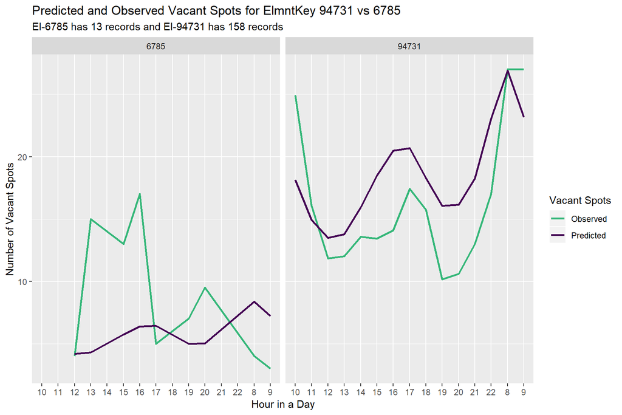

### 4.2 Measure of Accuracy - MAE

Figure below is the map of Mean Absolute Error Across Space. The predicting power is stronger in downtown area rather than peripheral area.

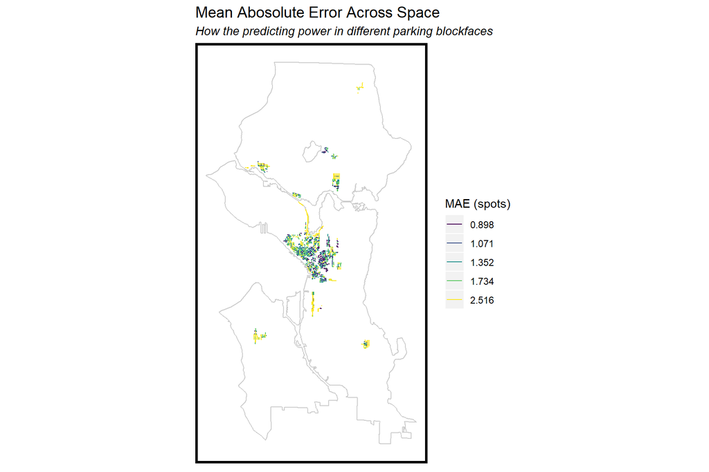

We ran **Moran’s I test** to examine whether there is spatial autocorrelation in the error in different parking blockface. The Moran’s I is `-0.0417` and the **p-value** of Moran I is `0.993`, which is over 0.05. The Moran I is calculated close to zero. This means that there is no spatial autocorrelation. That is to say that, the model should be generalizable and doesn’t have systematic bias across space.  
However, the Moran’s I test result is different as the MAE’s. One reason is that when calculating Moran’s I, most of time, it is calculating the downtown area. Therefore, the result of Maron I is different from what we visually see in the MAE map.

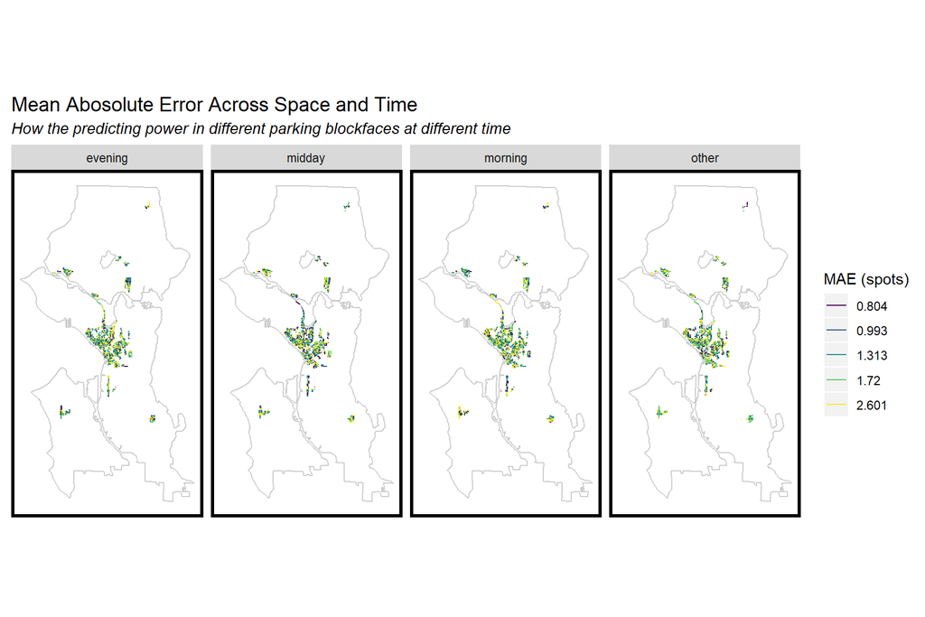

### 4.3 Out-of-sample Model and Cross-validation

#### 4.3.1 25% Training Set

25% test-sample prediction should be more trustworthy than the in-sample prediction. From the above analysis, we have already known that in-sample prediction model is relatively sensitive to outliers and data mining. In general, 25% test-sample prediction model may better reflect the available information.

The goal for our predictive model is to be generalizable. In other word, the model should be distributed spatially. The data was separated into two parts-25% randomly selected test set and 75% training set for remaining data. By doing so, we can judge the performance of the model.

Here is the polished result for the 25% test-sample set. The Mean Absolute Error (MAE) of the test set is around **2.11**. The result shows that the accuracy is moderate, and the generalizability is not that good

The mean absolute error of 25% training set is **2.12**. The 25% training model is less accurate than the in-sample model.

#### 4.3.2 K-fold Cross-validation

We use the cross-validation to test the generalizability of our model. The algorithm, we use in the test, is called “k-fold cross-validation (k-100)”. In other words, the original dataset is randomly partitioned by 100 equal sizes of subsamples. Then we can tell the effectiveness of the model. The place where the model may not be generalizable was where our model needs to improve.

Here is the result for the cross-validation (K=100), The Mean Absolute Error is around **1.9**. The accuracy is moderate. That is, for instance, if that space has 10 actual vacant spots, the model will give the result with either 8 or 12 spots.

Result of Cross-validation

| RMSE | RSquared | MAE | Standard Deviation of MAE |
| --- | --- | --- | --- |
| 2.838659 | 0.3913993 | 1.904212 | 0.0390463 |

Here is the histogram of the Mean Absolute Error (Poisson distribution).

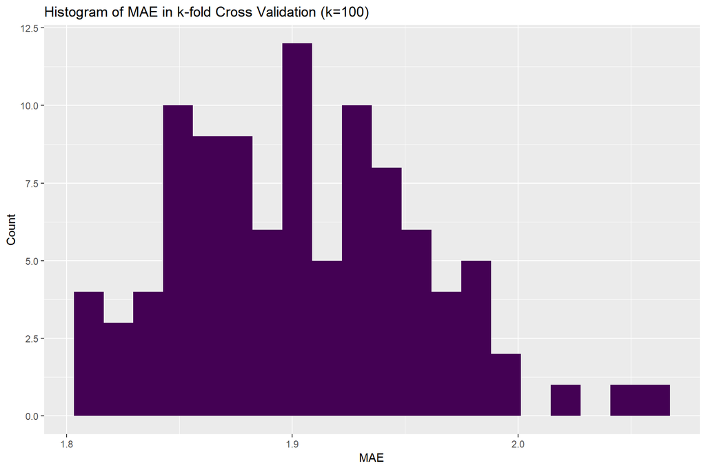

### 4.4 Generalizability Across Time and Space

#### 4.4.1 Spatial Cross-validation

In order to do the spatial cross-validation, we separate our study area into three neighborhood area: downtown area, peripheral area at University District, and residential area at Capitol Hill.

MAE in Different Neighborhoods

| Neighborhood | MAE |
| --- | --- |
| CBD (Downtown) | 1.733867 |
| University District (Peripheral) | 2.922975 |
| Capitol Hill (Residential) | 1.953299 |

We can see that the university district, which at the peripheral of Settle, obtains the largest mean absolute error (2.92). In center business district, which at downtown of Seattle, performs the best with the smallest mean absolute error (1.73). The residential area performs quite close to the original 25% test-sample model. The possible reason that causes this result might be due to the lack of data at the peripheral area. Most data are in the downtown. Therefore, this result also incrementally prove that this model is not generalizable enough to apply to all neighborhoods.

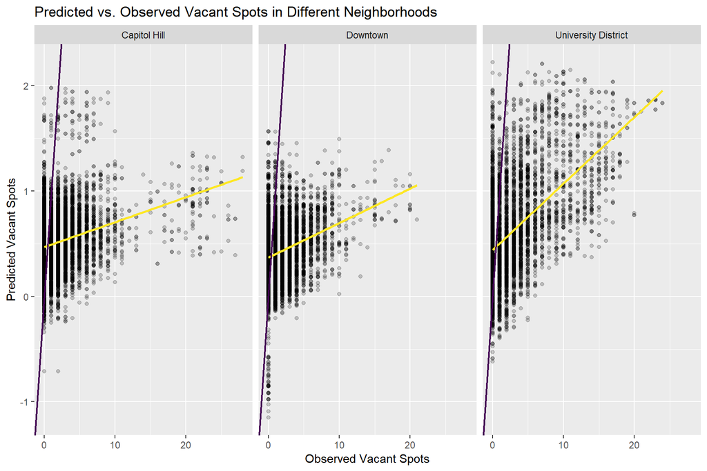

#### 4.4.2 Temporal Cross-validation

Temporal cross-validation can help us to test the generalizability of the temporal variables.

First, we hold out Thursday’s data in the dotw (day of week). Then we use Tuesday and Wednesday’s data to to predict Thursday’s vacant spots. In the figure below, yellow line is the predicted model; purple line is the predicted perfect model. The mean absolute error (MAE) of predicted model and the original Thursday’s data is 2.12. This means that the accuracy of this model is worse than the original model. Moreover, the generalizability of this model is not good as well. Therefore, comparing with every week’s model, thursday’s model is not generalizable enough to predict the other day of the week.

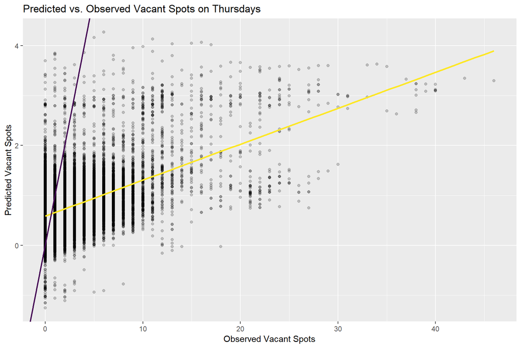

To analyze the influence of the variable of time of day. We hold out the mid-day data in time of day variable. Then we use evening data and morning data to predict mid-day’s vacant spots. We can see midday’s predicted model performs better than evening’s and morning’s, whose mean absolute error is 1.87. Overall, the generalizability of all these three model is not good.

MAE in Different Time

[output not shown]

As we mentioned before in the exploratory analysis part. The variable of peak hour seems to have more influence on the vacant spots. To analyze the performance of the peak hour, we also hold out the peak hour in the model. The result of the mean absolute error is quite well, which is 1.34. It is better than the original model. This means that peak hour performs better in the model.

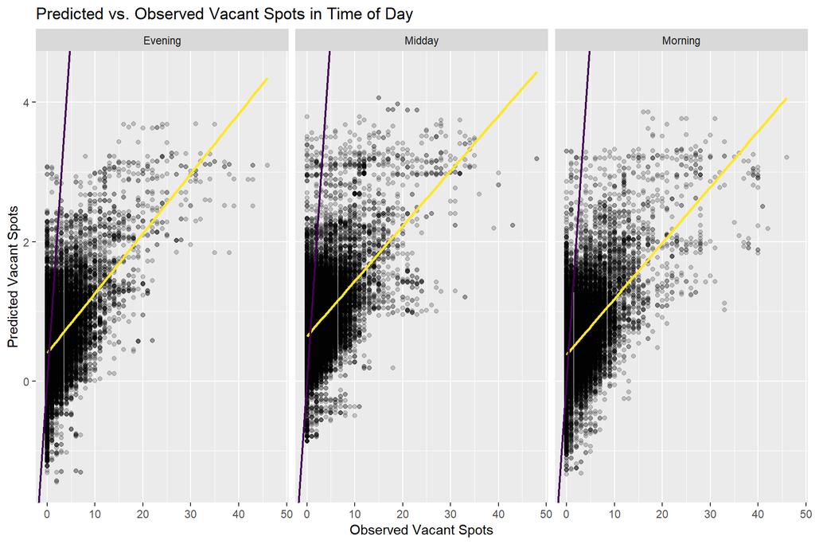

## 5 Discussion

The model is not effective enough since our MAE is around 1.82 for our in-sample model. We still need to improve our model. When there are enough samples within the neighborhoods (in our model, most data are in the downtown area), the model will perform better than those that lack samples (those in peripheral areas). Moreover, the model is not generalizable enough. This means that the performance of model varies across different neighborhoods. Therefore, as long as we have enough data within the study neighborhood, our model can perform quite well.

Peak Hour perform quite well as a temporal variable in our model, even rather than time variable itself. This means that peak hour does matter and will cause different results of vacant spots. This finding can also explain our assumption at the beginning of this report. Since most peak hours will highly be associated with traffic congestion, and vacant spots will also be affected by traffic congestion.

Distance to schools and distance to garages have a good performance in our model as spatial variables. While the distance to CBD does not has an obvious performance. The possible reason might be that most of the data are already within the CBD. Therefore, they have the same relations with this variable.

We use the 25%-sample models to test the effectiveness and generalizability of the model. MAE in the test set is 2.12, which has a worse result than the in-sample model. The variation of the numbers of vacant spots will reach to 2 spots. The accuracy result is moderate. However, the model is hard to apply to the other district except using in the downtown area. That is, the model predicts quite well within CBD, but relatively worse in Capitol Hill and University District (which are both outside the CBD boundary.) The probable reason may also relate to lack of sample data outside downtown.

In the spatial-lag model and temporal-lag model, both show that the model is not generalizable enough. This result will also relate to the uneven allocation of time data. In general, our model seems not to be that effective and needs to be improved.

## 6 Conclusion

We will still confidently recommend our model to the public, even though the effectiveness of the model still needs to be improved. Our model still can help the public to find a vacant spot in a timely manner or help people to decide whether they should drive their car in that period (especially peak hours in downtown). We can also offer some most important variables to help people to make their final decisions. For example, if the parking spots are close to a school, people should avoid these streets; if it is peak hour, people should better not try to park their car in the downtown.

To improve our model, we will recommend people to include business permission into the model. Because the scale of neighborhood variable is still too big to predict the model. Business permission can separate business areas (such as commercial, residential, or mixed-use) on a smaller scale. To access better generalizability, we suggest to highly include more data outside the downtown area.

#### Reference

1. Dowling, Chase & Fiez, Tanner & Ratliff, Lillian & Zhang, Baosen. How Much Urban Traffic is Searching for Parking? https://www.researchgate.net/publication/313879093_How_Much_Urban_Traffic_is_Searching_for_Parking
2. Fichman, Michael. 2016. An Evaluation of Pittsburgh’s Dynamically-Priced Curb Parking Pilot.